# Assignment 7

Cornelius Senf

28.11.2017

**Exercise:** In an experiment, the diameter of Tetrahymena cells (free-living ciliate protozoa) was measured in cultures of varying cell density and with and without glucose supplement (= additional energy). Using a linear regression approach, analyze the data to address the following questions: (1) Does cell concentration influence cell growth? (2) If so, does the effect vary between cell cultures with glucose supplement and witout?

## 1. Import and prepare the dataset (1 Point)

The data is on Moodle.

```r
dat <- read.table("Data/tetrahymena_zellen.txt", sep = "\t", header = TRUE)
dat$glucose <- factor(dat$glucose)
```

## 2. Visualize the data (2 Points)

Create a scatterplot to explore the relationships between concentration, diameter and glucose supplement. Is the relationship linear? If not, how can you correct for it? Hint: Transforming a predictor might help! Briefly describe your thoughts on the relationships and the effects you might expect.

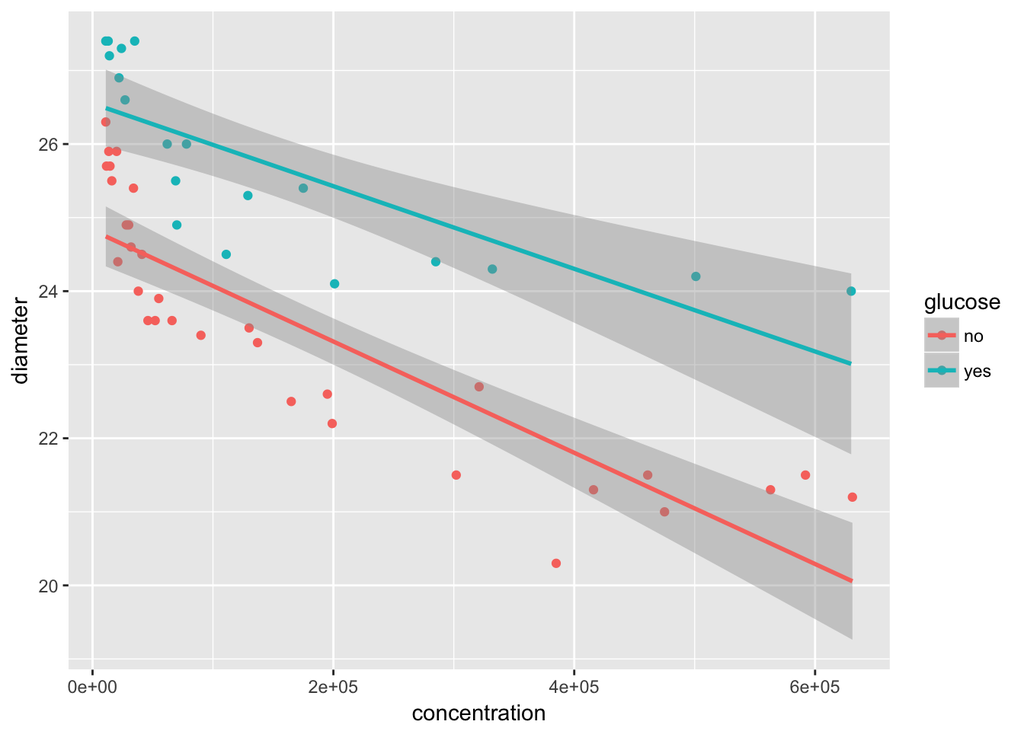

```r
library(ggplot2)

ggplot(dat, aes(x = concentration, y = diameter, col = glucose)) +
  geom_point() +
  geom_smooth(method = "lm")
```

Log-transforming the concentration improves the fit as concentration is boundeed to positive values.

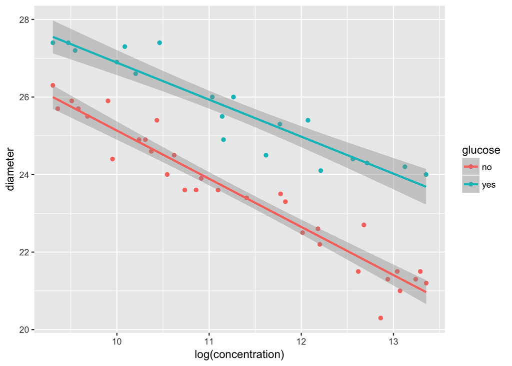

```r
ggplot(dat, aes(x = log(concentration), y = diameter, col = glucose)) +
  geom_point() +
  geom_smooth(method = "lm")
```

## 3. Build a simple linear model (2 Points)

Build an appropriate linear model between diameter (response) and concentration (predictor) and visualize it graphically. Assess the assumptions and the goodness-of-fit of the model. Briefly describe your findings.

```r
fit <- lm(diameter ~ log(concentration), data = dat)
summary(fit)
```

```
##
## Call:
## lm(formula = diameter ~ log(concentration), data = dat)
##
## Residuals:
##     Min      1Q  Median      3Q     Max
## -2.1719 -0.8234 -0.4670  0.9805  2.1140
##
## Coefficients:
##                    Estimate Std. Error t value Pr(>|t|)
## (Intercept)         37.5654     1.4271  26.322  < 2e-16 ***
## log(concentration)  -1.1736     0.1258  -9.331  1.9e-12 ***
## ---
## Signif. codes:  0 '***' 0.001 '**' 0.01 '*' 0.05 '.' 0.1 ' ' 1
##
## Residual standard error: 1.15 on 49 degrees of freedom
## Multiple R-squared:  0.6399, Adjusted R-squared:  0.6326
## F-statistic: 87.08 on 1 and 49 DF,  p-value: 1.901e-12
```

Compare fitted values to residuals:

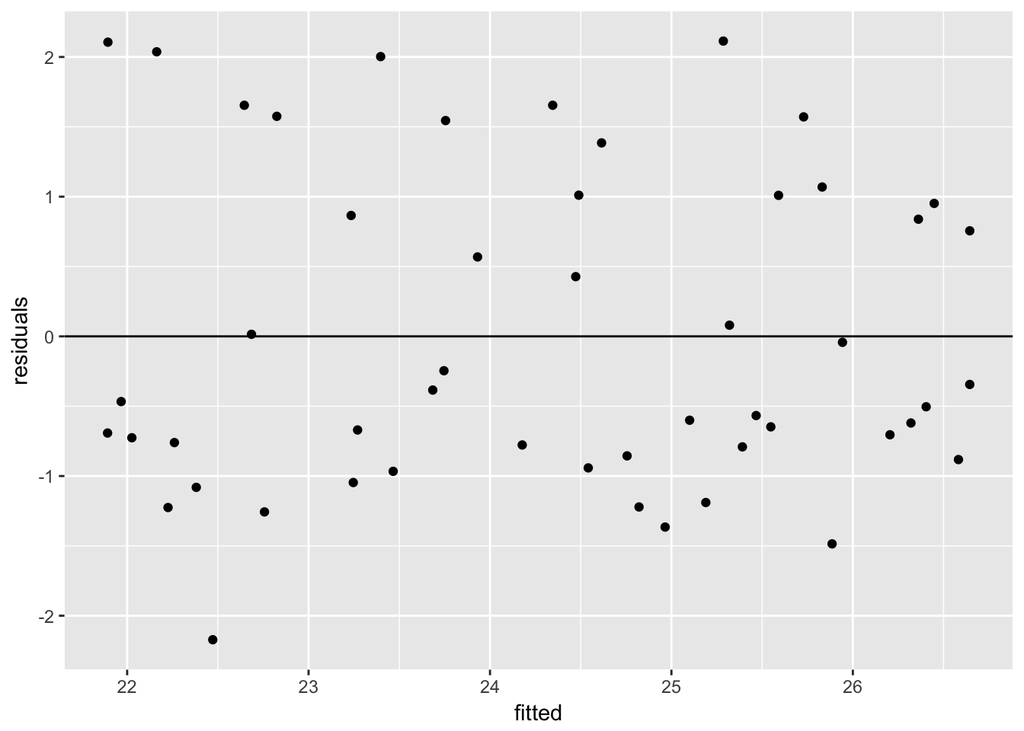

```r
resids <- data.frame(residuals = residuals(fit),
                     fitted = fitted(fit))

ggplot(resids, aes(x = fitted, y = residuals)) +
  geom_point() +
  geom_hline(yintercept = 0)
```

Check for normality of residuals:

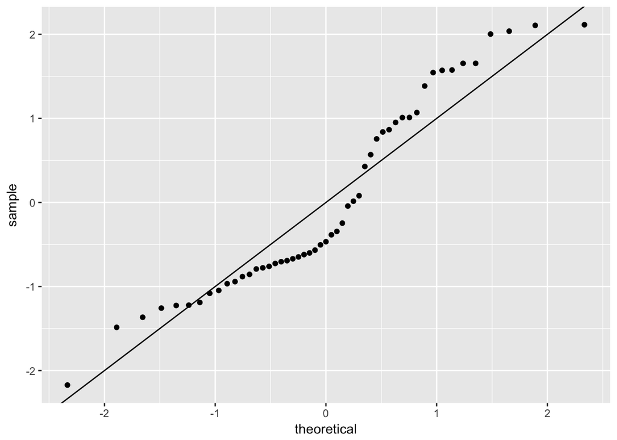

```r
ggplot(resids, aes(sample = residuals)) +
  stat_qq() +
  geom_abline(intercept = 0, slope = 1)
```

## 4. Multiple linear model (2 Points)

Now build a multiple linear model by adding glucose as additional predictor interacting with concentration. Compare your model to the previous one based on the AIC. Does including glucose improve the model fit?

```r
fit2 <- lm(diameter ~ log(concentration) * glucose, data = dat)
summary(fit2)
```

```
##
## Call:
## lm(formula = diameter ~ log(concentration) * glucose, data = dat)
##
## Residuals:
##     Min      1Q  Median      3Q     Max
## -1.2793 -0.1912  0.0118  0.2656  0.9552
##
## Coefficients:
##                               Estimate Std. Error t value Pr(>|t|)
## (Intercept)                   37.55942    0.71381  52.618   <2e-16 ***
## log(concentration)            -1.24252    0.06269 -19.820   <2e-16 ***
## glucoseyes                    -1.12244    1.21868  -0.921   0.3617
## log(concentration):glucoseyes  0.28753    0.10768   2.670   0.0104 *
## ---
## Signif. codes:  0 '***' 0.001 '**' 0.01 '*' 0.05 '.' 0.1 ' ' 1
##
## Residual standard error: 0.4659 on 47 degrees of freedom
## Multiple R-squared:  0.9433, Adjusted R-squared:  0.9397
## F-statistic: 260.8 on 3 and 47 DF,  p-value: < 2.2e-16
```

Comparing both models using AIC:

```r
AIC(fit, fit2)
```

```
##      df      AIC
## fit   3 162.9735
## fit2  5  72.6605
```

AIC suggests that fit2 should be preferred over fit (smaller AIC).

## 5. Plot the regression lines of the multiple linear model (3 Points)

Plot the regression line for the multiple-regression model, that is one line for each class (glucose/no glucose).

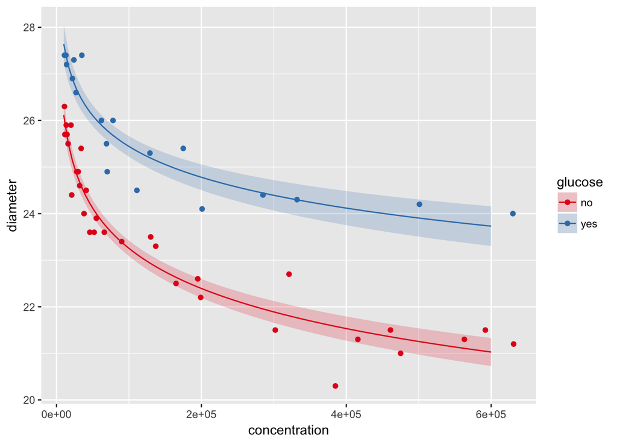

```r
library(effects)

efct <- effect("log(concentration):glucose", mod = fit2,
               xlevels = list(concentration = seq(1e+04, 6e+05, length.out = 100)),
               confint = list(compute = TRUE))
efct <- as.data.frame(efct)

ggplot() +
  geom_ribbon(data = efct, aes(x = concentration, ymin = lower, ymax = upper, fill = glucose), alpha = 0.2) +
  geom_point(data = dat, aes(x = concentration, y = diameter, col = glucose)) +
  geom_line(data = efct, aes(x = concentration, y = fit, col = glucose)) +
  scale_color_brewer(palette = "Set1") + # See http://colorbrewer2.org/ for hints on nice color-schemes!
  scale_fill_brewer(palette = "Set1")
```